# Analysis of Mass Incarceration in the United States

Elizabeth Deng

2022-11-26

## Abstract

This data analysis project looks at statistics from the Vera Institute regarding incarceration rates in America. The dataset spans several decades and all 50 states, and we will use it to depict trends in incarceration demographics  
over time.

## I. Introduction

> “The United States is home to less than 5 percent of the world’s population, yet nearly 16 percent of all incarcerated people—roughly two million people— are held in our jails and prisons. We incarcerate more people per capita than any country in the world.” *Source: [Vera Institute](https://www.vera.org/ending-mass-incarceration)*

This data set from the Vera Institute addresses the pressing social issue of mass incarceration and its  
effects on communities— specifically, and disproportionately, on impoverished communities and communities of color. Factors including (but not limited to): over-policing of poor areas, the monetary bail system, racial disparities in stops and arrests, and a weakened public defender system *all* contribute to the matrix of domination being upheld. An unjust legal and incarceration system maintains a power structure, which is what the Vera Institute aims to challenge.

The following data analysis questions the current incarceration system’s inequities in terms of race and location. The dataset from the Vera Institute has variables that address both jail and prison admissions, the rate of admission/population by race and gender, reasons for jail holding, and more. A dataset with this variety of variables is very helpful in addressing values of equity, power, and justice.

This report analyzes the following questions:  
1. How has the national population of imprisoned individuals changed in the past few decades?  
2. How do changes in prison population differ across states?  
3. Are certain races disproportionately represented in prison?  
4. Does the urbanicity of an area affect its prison racial demographics?  
5. Which states have the highest rates of prison admissions?

## II. Data Summary

I began my data analysis by first narrowing the dataset down to only Washington state. I wanted to look at the growth of the jail and prison populations in comparison to the growth of the overall population.

Between the years 1995 and 2016, Washington state had a total population growth of **33.18%**. However, the population of individuals in jail grew by **40.11%** and the population of individuals in prison grew by **48.71**%.

Then I broadened the analysis to the entirety of the United States. The most recent year that had the most available data was 2016, so the analysis focuses on that year.

Across all 50 states, the average white population was **67.12**%, the average black population was **13.66**%, and the average Latino population was **12.98**%. However, these proportions are not the same in states’ prison populations. The average percentage of prisoners who were white, black, and Latino were **43.23**%, **39.02**%, and **12.99**% respectively. We would expect the proportion of races to be about the same across the general population and the prison population; however, fewer white people are imprisoned at the same time that more black people are.

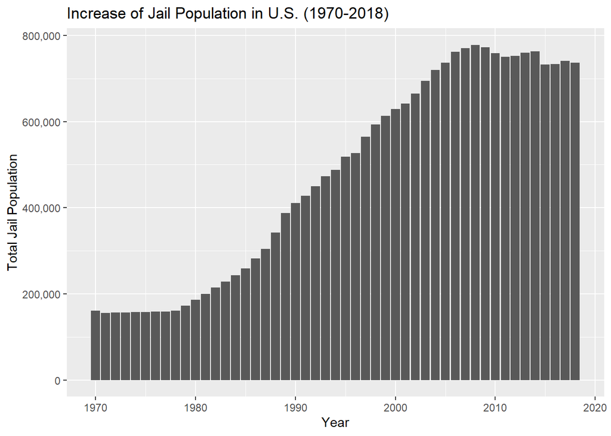

**CAPTION: The total population of individuals in U.S. jails over the course of 48 years.**

*Analysis*

The overarching questions regarding mass incarceration are: how has the state of incarceration changed over the years, and what could be the cause? The graph depicts a steep incline in jail population, beginning in around 1980. Between 1970 and 2018, the national jail population grew by over 500,000, which again prompts the question: why?

[figure not shown]

**CAPTION: A line graph depicting changes in jail population between 1970-2018, in Massachusetts, Arizona, Tennessee, Colorado, Alabama, Maryland, and Washington.**

## V. Prisoner Race Proportions By Urbanicity

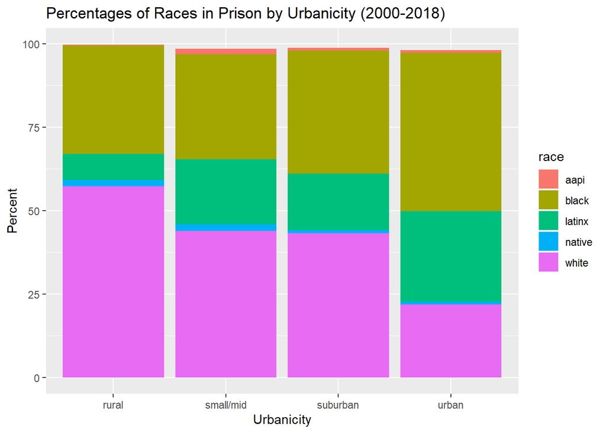

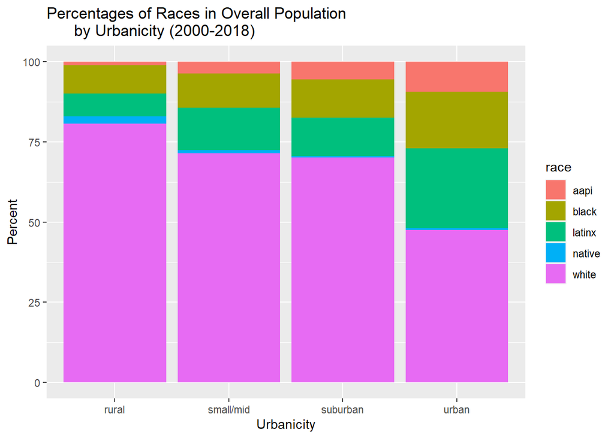

**CAPTION: The first stacked bar chart depicts the racial proportions of prison populations for all four levels of urbanicity. The second chart depicts the racial proportions of the *overall* populations.**

*Analysis*  
The variables I chose to compare were the racial proportions of the prison populace compared to the overall populace, and how these proportions differed based on the urbanicity of a location. These charts were calculated by finding the average percentage of each race in all prisons across the U.S., then the average percentage of each in the whole of the country.

My questions were:  
1. How do racial demographics in prison compare to the racial demographics of America as a whole?  
2. Do racial proportions differ by urbanicity?

The resulting charts clearly indicate that although most of the country is white, a smaller proportion of the national prison populace is white. Additionally, Black and Latinx individuals comprise a larger proportion of the prison population than they do in the overall population. It’s also noticeable that more POC are imprisoned as urbanicity shifts from rural to urban.

## VI. State Prison Admissions

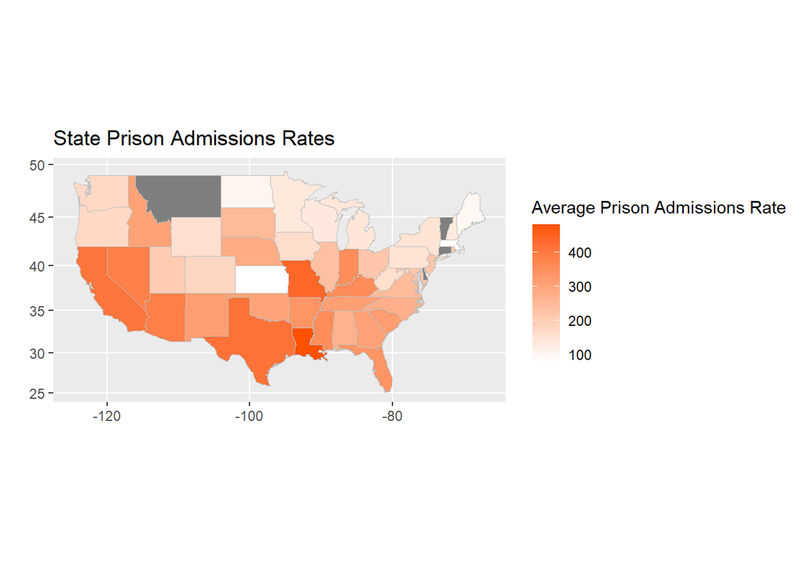

**CAPTION: A chloreopleth map depicting average prison admission rates by state, with the highest rates in orange. States in gray did not have data available.**

*Analysis*

The variable depicted in the map is the total prison admissions rate for each state. Several states did not have sufficient available data; these are shown on the map in gray.